# Meredith Franklin

[GitHub Profile](https://github.com/meredithfranklin)  
[Home](http://meredithfranklin.github.io)  
Research  
[Courses](https://github.com/meredithfranklin/courses/tree/master/)  
R Tutorials

## R Tutorials

**Introduction to R**

- R Fundamentals
- Basic Statistics
- Control Structures and Writing Functions
- Plotting and ggplot2

**Distributions and Inference**

- Distributions
- Statistical Tests
- Optimization and Likelihood

**Regression**

- Linear Regression
- Regression Diagnostics
- Logistic Regression
- Semi-Parametric Regression

**Spatial Statistics**

- Geostatistics
- Areal Data
- Point Process Data

# R-Probability-Distributions

All of the common distributions are available in R, and for every distribution R can calculate various properties. There is a root name for each distribution (e.g `norm` for the normal distribution) and the following prefixes to the name of the distribution to do the following:

`d` to generate the probability mass or density function  
Example: `dnorm(x,mean,sd)`

`p` to generate the probability $P(X \le x)$ (the cdf)  
Example: `pnorm(q,mean,sd)`

`q` to generate the quantile $P(X \le x) > q$ (inverse cdf)  
Example: `qnorm(p,mean,sd)`

`r` to generate a random variable having the specified distribution  
Example: `rnorm(n,mean,sd)`

Distributions in R with their function names and function requirements (generally values of distribution parameters)

| Distribution | Functions | Specifications |
| --- | --- | --- |
| [beta](https://stat.ethz.ch/R-manual/R-devel/library/stats/html/Beta.html) | `dbeta` `pbeta` `qbeta` `rbeta` | shape parameters $\alpha$ and $\beta$ |
| [binomial](https://stat.ethz.ch/R-manual/R-devel/library/stats/html/Binomial.html) | `dbinom` `pbinom` `qbinom` `rbinom` | number of trials and probability of success on each trial |
| [cauchy](https://stat.ethz.ch/R-manual/R-devel/library/stats/html/Cauchy.html) | `dcauchy` `pcauchy` `qcauchy` `rcauchy` | location $\alpha$ and scale $\beta$ parameters |
| [chi-square](https://stat.ethz.ch/R-manual/R-devel/library/stats/html/Chisquare.html) | `dchisq` `pchisq` `qchisq` `rchisq` | degrees of freedom |
| [exponential](https://stat.ethz.ch/R-manual/R-devel/library/stats/html/Exponential.html) | `dexp` `pexp` `qexp` `rexp` | rate $\lambda$ |
| [F](https://stat.ethz.ch/R-manual/R-devel/library/stats/html/Fdist.html) | `df` `pf` `qf` `rf` | numerator and denominator degrees of freedom |
| [gamma](https://stat.ethz.ch/R-manual/R-devel/library/stats/html/GammaDist.html) | `dgamma` `pgamma` `qgamma` `rgamma` | shape $\alpha$ and scale $\beta$ parameters |
| [geometric](https://stat.ethz.ch/R-manual/R-devel/library/stats/html/Geometric.html) | `dgeom` `pgeom` `qgeom` `rgeom` | probability of success |
| [hypergeometric](https://stat.ethz.ch/R-manual/R-devel/library/stats/html/Hypergeometric.html) | `dhyper` `phyper` `qhyper` `rhyper` | number in group 1 ($n$), number in group 2 ($m$), number drawn ($k$) |
| [logistic](https://stat.ethz.ch/R-manual/R-devel/library/stats/html/Logistic.html) | `dlogis` `plogis` `qlogis` `rlogis` | location and scale parameters |
| [lognormal](https://stat.ethz.ch/R-manual/R-devel/library/stats/html/Lognormal.html) | `dlnorm` `plnorm` `qlnorm` `rlnorm` | mean $\mu$ and standard deviation $\sigma$ on the log scale |
| [negative binomial](https://stat.ethz.ch/R-manual/R-devel/library/stats/html/NegBinomial.html) | `dnbinom` `pnbinom` `qnbinom` `rnbinom` | number of trials and probability of success on each trial |
| [normal](https://stat.ethz.ch/R-manual/R-devel/library/stats/html/Normal.html) | `dnorm` `pnorm` `qnorm` `rnorm` | mean $\mu$ and standard deviation $\sigma$ |
| [poisson](https://stat.ethz.ch/R-manual/R-devel/library/stats/html/Poisson.html) | `dpois` `ppois` `qpois` `rpois` | rate parameter $\lambda$ |
| [t](https://stat.ethz.ch/R-manual/R-devel/library/stats/html/TDist.html) | `dt` `pt` `qt` `rt` | degrees of freedom |
| [uniform](https://stat.ethz.ch/R-manual/R-devel/library/stats/html/Uniform.html) | `dunif` `punif` `qunif` `runif` | min and max ($\theta_1$ and $\theta_2$) of the distribution |
| [weibull](https://stat.ethz.ch/R-manual/R-devel/library/stats/html/Weibull.html) | `dweibull` `pweibull` `qweibull` `rweibull` | shape $\alpha$ and scale $\beta$ parameters |

#### Using `d` functions

The `d` functions find the pmf for discrete distributions and the pdf for continuous distributions, namely returning the probability density for a given value of random variable X, $P(X=x)$. For a given range of values $x_1,...,x_n$, we can find the density and plot the density function. For example, to generate the standard normal pdf, define some observations x, and apply `dnorm` with $\mu=0$ and $\sigma=1$ (note these are the default values of dnorm):

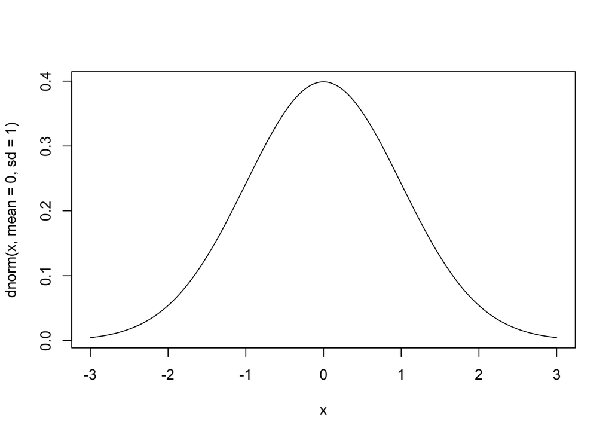

```r
x <- seq(-3,3,0.01)
# Plot Normal Distribution
plot(x=x, y=dnorm(x, mean=0, sd=1), type='l')
```

Let’s look at the t distribution with different degrees of freedom and compare it to the standard normal distribution

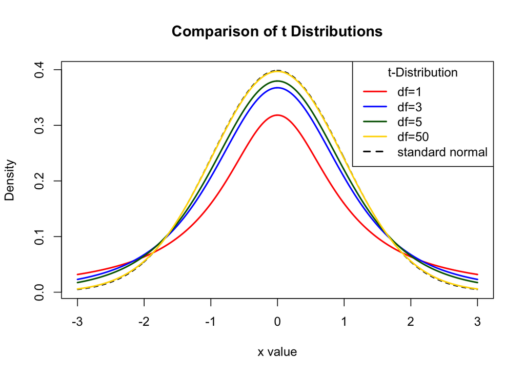

```r
# provide same x observations as above
x <- seq(-3,3,0.01)
# try different degrees of freedom
df <- c(1, 3, 5, 50)
# set up colours and labels for the functions and plot legend
colors <- c("red", "blue", "darkgreen", "gold", "black")
labels <- c("df=1", "df=3", "df=5", "df=50", "standard normal")
# plot Z first
plot(x, dnorm(x), type="l", lty=2, xlab="x value",
     ylab="Density", main="Comparison of t Distributions")
# add lines representing t-distribution
for (i in 1:4){
  lines(x, dt(x,df[i]), lwd=2, col=colors[i])
}
# add legend
legend("topright", title="t-Distribution",
       labels, lwd=2, lty=c(1, 1, 1, 1, 2), col=colors)
```

We see how when df->$\infty$, t converges to the standard normal distribution.

For a binomial random variable, suppose you take a multiple choice exam with 10 questions. Each question has 5 possible answers, with only one being correct. You didn’t study so guess the answers. What is the probability of getting exactly 6 correct Pr(X=6)?

```r
dbinom(6,size=10,prob=1/5)
```

```
[1] 0.005505024
```

The distribution of all possible results on the test

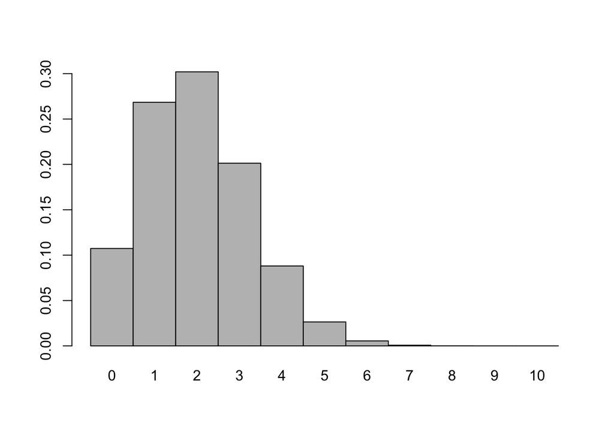

```r
y<-dbinom(0:10,size=10,prob=1/5)
barplot(y,space=0,names.arg=c(0:10))
```

#### Using `p` functions

The `p` functions find $F(x) = P(X \le x)$, thus providing the probability for the “lower tail” of the distribution. Basically, this function will return the probability for which a given number or a vector of numbers is less than or equal to a value. Should we wish to find the probability for the “upper tail”, we can choose the option `lower=FALSE` in any of the distribution functions. For example, an application of the Poisson distribution:  
Suppose there are on average 10 asthmatic patients that come to a particular health clinic on a given day. What is the probability that only 4 will come to the clinic today?

```r
ppois(4,lambda=10)
```

```
[1] 0.02925269
```

This is the probability that 4 or fewer will come to the clinic today. The probability of 5 or more coming to the clinic will be

```r
ppois(4,lambda=10, lower=FALSE)
```

```
[1] 0.9707473
```

An example using the normal distribution, suppose we have data between -2 and 2 and we wish to find the probabilities of their values given that they come from a normal population with mean -1 and standard deviation 1. We plot the probabilities against each value of our random variable X.

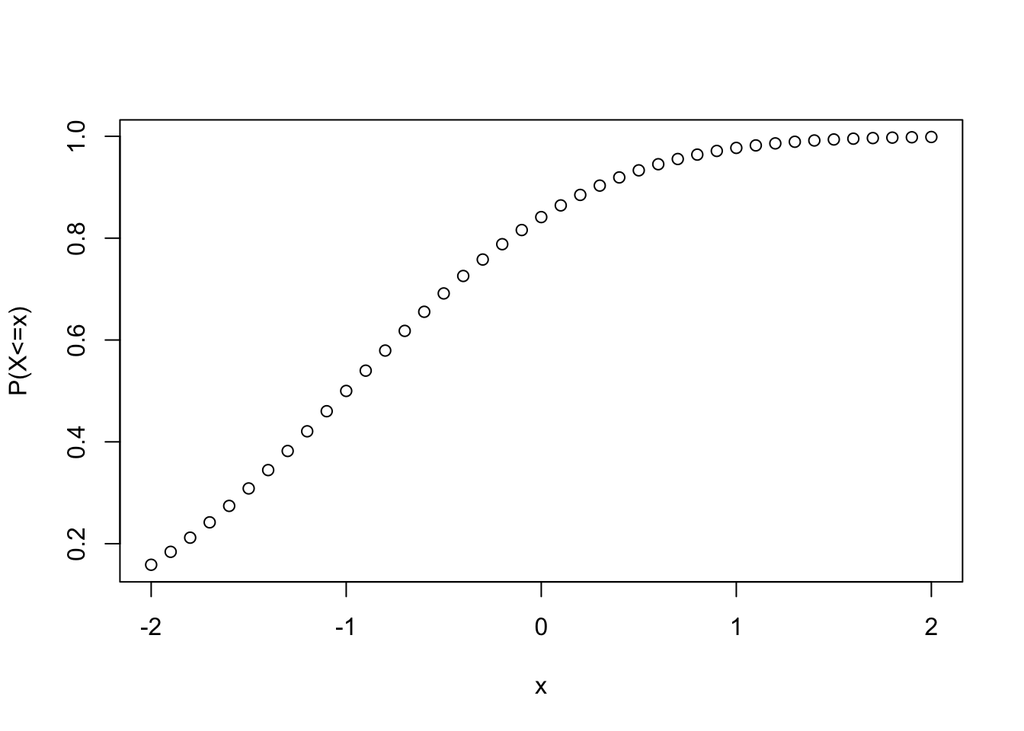

```r
x <- seq(-2,2,by=0.1)
y <- pnorm(x,mean=-1,sd=1)
plot(x,y, ylab="P(X<=x)",xlab="x")
```

#### Using `q` functions

The `q` functions are the inverse of the `p` functions, meaning that for a given probability the quantile (percentile) value q for the cumulative distribution will be returned $P(X \le x) > q$. For instance, for a standard normal distribution the `qnorm` function for p=0.95 will return the z-score 1.64.

```r
qnorm(0.95,mean=0,sd=1)
```

```
[1] 1.644854
```

Another example: find the 99th percentile of the $\chi^2$ distribution with 6 degrees of freedom.

```r
qchisq(0.99,6)
```

```
[1] 16.81189
```

#### Using `r` functions

The `r` functions generate a random sample of a specified size from the distribution of choice.  
Let’s generate 7 observations from a uniform distribution on the interval [1,5] and sort it in ascending order

```r
x<-runif(7,1,5)
sort(x)
```

```
[1] 1.292336 1.903070 2.845815 3.267600 4.196206 4.705819 4.725922
```

#### Additional uses of the functions

Suppose we know IQ scores are normally distributed with a mean of 100 and a standard deviation of 15. What proportion of children are expected to have an IQ between 80 and 120? This is an application of `pnorm`, and if we wish to plot the area under the normal distribution that corresponds to this area, we additionally apply `dnorm`.

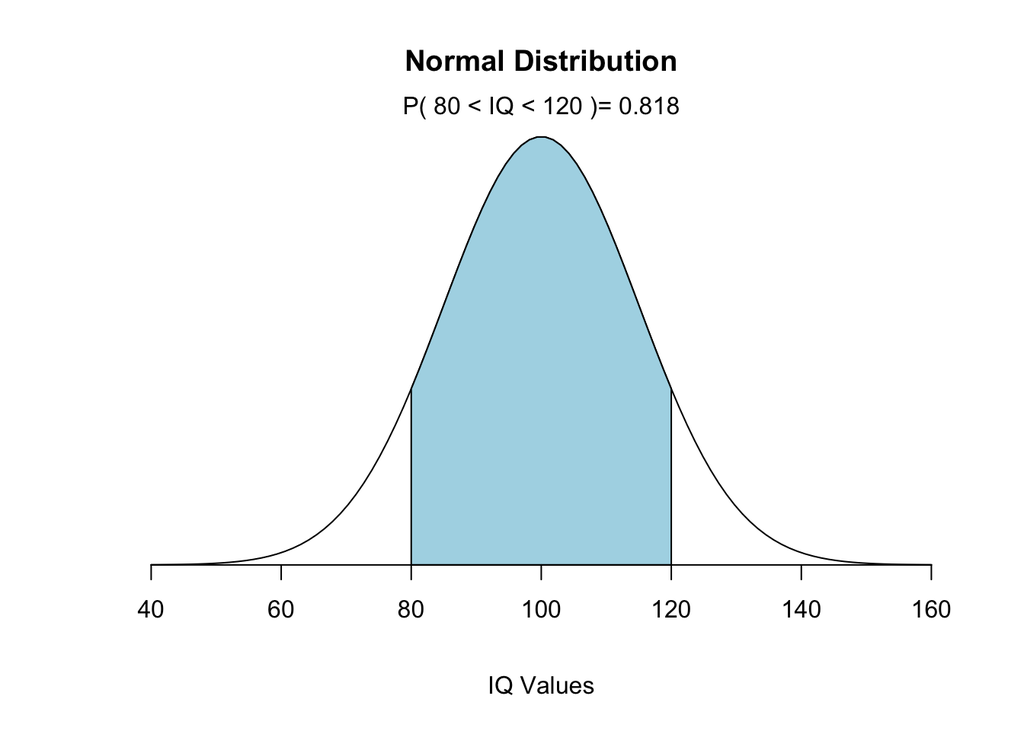

```r
# set up necessary parameters
mean=100
sd=15
lb=80
ub=120
# create vector of x's: 100 observations around the given mean and sd
x <- seq(-4,4,length=100)*sd + mean
# find probabilities for these values given the distribution parameters
hx <- dnorm(x,mean,sd)
# plot
plot(x, hx, type="n", xlab="IQ Values", ylab="", main="Normal Distribution", axes=FALSE)
# add lines at the upper and lower bounds
i <- x >= lb & x <= ub
lines(x, hx)
# create polygon for shading area of distribution
polygon(c(lb,x[i],ub), c(0,hx[i],0), col="lightblue")
area <- pnorm(ub, mean, sd) - pnorm(lb, mean, sd)
# add title and axis labels
mtext(paste("P(",lb,"< IQ <",ub,")=",signif(area, digits=3)),3)
axis(1, at=seq(40, 160, 20), pos=0)
```